# Iceplant imagery deep-dive: New Zealand, France, Portugal, Spain

Region × source comparison for deep-learning detection & validation

Published

September 9, 2026

**In this document**

1. **Summary** — quick overview and a country-ranking table across all criteria.
2. **Imagery & access spec** — the quantitative attributes as a graphic (dot = typical value, bar = range, per source), then a transposed table of the qualitative attributes (bands, format, extent, access, licence).
3. **Per-region deep-dive** — one tab per region: the coverage maps and imagery figures, with occurrences overlaid.
4. **Climatic similarity** — coastal climate analogs of the Dangermond preserve (GEnS v3), ranked per country, with per-region maps.
5. **Conservation overlap** — how much of each country’s iceplant sits in or near a coastal protected area (WDPA), scaled to its total occurrences.
6. **Validation Notes** — a few notes on potential validation data for each region.
7. **Open questions** — every `TODO` cell in one checklist for the research pass.
8. **Appendix — per-region notes** — the full written detail behind each region’s tab.

## Summary

**Previous decisions:**

- best to focus on one location for both validation and ease of analysis
- need to identify quality of imagery coverage within the short-listed countries (NZ, FR, PT, ES)
- identify other relevant factors that might influence decisions

Examined four countries (New Zealand, France, Portugal, Spain) for deep-learning *Carpobrotus* transfer work. Specifically looked more closely at:

- the number of years covered by imagery in each country
- the consistency / amount of coverage for each region in a typical survey
- the availability of near-infrared (NIR) bands
- the time of year the imagery was acquired (seasonality)
- potential existing validation data
- climatic similarity to Southern California (the target transfer region)
- proximity of the iceplant to coastal protected/conservation areas

**Methods**:

- examined imagery sources from each country by region (province, département, etc.)
- calculated avg. resolution, spatial coverage of surveys, and temporal depth (number of years with imagery)
- assessed the availability of NIR bands and seasonality of imagery acquisition
- assessed general seasonality of imagery
- examined google earth potential for validation
- searched for potential other existing datasets (coverage or mapping surveys) that could be used for validation
- identified climatic similarity of locations to Dangermond preserve
- measured how much of each country’s iceplant sits in/near coastal protected areas (WDPA)

**Results**:

Across the decision criteria, **France leads most often** (resolution, NIR, climatic similarity, conservation overlap, and the Street-View validation spot-check), has good temporal depth as well as multiple imagery sources. **New Zealand** is strong on temporal depth and seasonal fit, **Portugal** on per-survey coverage. The table below shows the actual value per criterion with the row leader highlighted.

**Where each country leads — criteria ranking**

Actual value per criterion; the leader on each row is highlighted.

|  | New Zealand | France | Portugal | Spain |
| --- | --- | --- | --- | --- |
| Spatial resolution (typical GSD) | 0.375 m | 0.20 m | 0.25 m | 0.25 m |
| Coverage per survey — % of region | 26% | 32% | ~94% (prov.) | 36% |
| Coverage per survey — absolute area | ~69,000 km² | ~177,000 km² | ~83,000 km² (prov.) | ~182,000 km² |
| Temporal depth (yrs w/ imagery per area) | 21 | 15 | 9–10 | 12 |
| NIR availability (% of surveys) | 22% | 100% | 100% | 94% |
| Seasonality (acquisition window vs bloom) | Nov–Mar | Apr–Jul | Jun–Aug | May–Sep |
| Climatic similarity (coastal analog %) | 64.3% | 66.4% | 48.2% | 36.2% |
| Conservation overlap (% inside coastal PA) | 34% | 83% | 76% | 62% |
| Field validation (GBIF hotspot Street View) | 3/5 | 5/5 | 8/10 | 2/5 |

**Highlight = leads that criterion.** Resolution, coverage, temporal depth, NIR and seasonality come from the spec sheet; climatic similarity is the coastal analog % from the Climatic similarity section. **Coverage is shown two ways:** *% of region* per campaign favours smaller countries (Portugal leads), while *absolute area* imaged per campaign favours larger ones (Spain leads, France close) — the area row = avg % × each country’s equal-area land, matching the km² panel of Figure 1. **Seasonality** is ranked by overlap with peak iceplant flowering (≈ **Feb–Jun** in Europe, ≈ **Oct–Feb** in New Zealand): NZ (Nov–Mar) and France (Apr–Jul) align, while Portugal (Jun–Aug) and Spain (May–Sep) largely miss it. **Portugal’s coverage (~94%) is provisional** — not yet data-derived (see Open research items). **Conservation overlap** is the share of a country’s *Carpobrotus* falling inside a coastal protected area (from the Conservation overlap section; France leads, and the figure is *not* coverage-adjusted). **Field validation** is a first-pass Street-View spot-check of GBIF hotspots — the fraction where iceplant was visible near the records (France 5/5 leads; see Validation Notes).

## Imagery & access spec

The **quantitative** attributes are a graphic (Figure 1); the **qualitative** attributes follow in the table below.

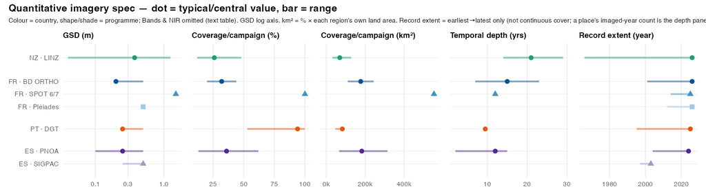

Figure 1: **Quantitative attributes.** One row per image source; **dot** = typical/central value, **bar** = its range. Colour = country, shape/shade = programme. GSD on a log axis. Coverage is shown both as **% of each region** and as **absolute km²** (= % × the region’s own land area, so different-sized countries compare directly). **Record extent** is earliest→latest *only* — not a claim of continuous cover; how many distinct years a given place actually has is the separate **Temporal depth** panel.

*Coverage is **data-derived** from metadata in the following scripts: Spain from `avail_es_pnoa_coverage.R` (per-year PNOA histórico WMS masks, 2004–2024); France from `avail_fr_bdortho_coverage.R` / `avail_fr_orthosat_coverage.R` (per-year WMS masks, 2001–2024; SPOT annual national since 2014; Pléiades coast-biased — 88% of the 10 km strip vs 40% overall); New Zealand from `avail_nz_linz_coverage.R` (LINZ survey-index footprints on regional councils, 1966–2026), computed identically. **Absolute-area** panels use each analysis’s own equal-area land denominator: NZ ≈ 267,000 km², metropolitan France ≈ 553,000 km², continental Portugal ≈ 88,000 km², Spain ≈ 507,000 km². Portugal’s coverage figures are **provisional**, pending its own data-derived analysis.*

**Imagery & access spec sheet — qualitative attributes**

Categorical / text rows; the quantitative attributes are the graphic above.

|  | **New Zealand** LINZ (S3) | **France · BD ORTHO** aerial 0.20 m | **France · ORTHO-SAT** SPOT 6/7, 1.5 m | **France · ORTHO-SAT** Pléiades, 0.50 m | **Portugal** DGT Ortofotos | **Spain · PNOA** histórico + actual | **Spain · SIGPAC** pre-PNOA |
| --- | --- | --- | --- | --- | --- | --- | --- |
| Imagery |  |  |  |  |  |  |  |
| Bands (n) | 4 | 3+3 (RGB/IRC) | 4 | 4 | 4 | 4 | 3 |
| NIR coverage (% of surveys) | 22% | 100% | 100% | 100% | 100% | 94% (sep.) | 0% |
| Format | COG | JPEG 2000 | GeoTIFF | GeoTIFF | GeoTIFF (COG) | COG | ECW |
| Ongoing | Yes | Yes | Yes | Yes | Yes | Yes | No |
| Nominal revisit (yr) | varies | 3 | 1 | on-demand | 3 | 2–3 | — |
| Extent | National | National (metro + DROM) | National (metro + DROM) | Coastal + inland AOI | Continental PT | National | National |
| Seasonality | 76% Nov–Mar (85% Oct–Apr) | 70% Apr–Jul (all Mar–Oct) | Mar–Sep (spec; mtns summer) | Opportunistic (on-demand) | Jun–Aug core (Mar–Oct) | May–Sep (spec; mainland) | — TODO research — |
| Access |  |  |  |  |  |  |  |
| Access route<sup>1</sup> | Public S3 (no key) | IGN Géoservices WMS/WMTS | IGN Géoservices WMS/WMTS | IGN Géoservices WMS/WMTS | CDD download + DGT WMS/WMTS | CNIG Descargas + WMS/OGC | CNIG Descargas (ECW/MTN50) |
| Auth required | No | No | No | No | No | No | No |
| Licence | CC-BY 4.0 | Licence Ouverte | Licence Ouverte | Licence Ouverte | CC-BY 4.0 | CC-BY 4.0 | CC-BY 4.0 |

<sup>1</sup> **Download cost — coastal, one typical year.** The tile footprint is what makes the per-year file count diverge by orders of magnitude, *not* coast length. To pull the 10 km coastal strip for one representative campaign year is ≈ **28,300** files for New Zealand (tiny 0.35 km² COGs), ≈ **7,900** for France · BD ORTHO and ≈ **21,500** for Pléiades (1 km² dalles; Pléiades counts its multi-year *union*, being on-demand), ≈ **560** for Portugal (10 km² tiles), and just ≈ **210** for Spain — but Spain’s are whole ~110 km² MTN25 sheets, so that’s ≈ 375 GB, the largest volume of all. Full derivation and per-file GB in `R/imagery/est_coastal_download_cost.R` → `outputs/tables/coastal_download_estimate.csv` (Spain enumerated exactly against the MTN25 grid; other rows = coastal-strip area ÷ tile footprint × campaign fraction; GB uses assumed compression).  
**Bands / NIR:** France · BD ORTHO is *acquired* 4-channel (R/G/B/NIR) but *delivered* as two separate 3-band products — RGB and IRC (near-infrared false-colour) — so `3+3`, not a single 4-band file (IGN *Descriptif de contenu BD ORTHO 2.0*); IRC per-year layers exist 2012–2024. ORTHO-SAT (SPOT / Pléiades) *are* native 4-band GeoTIFF. NZ 4-band share (≈22% of surveys) from `avail_nz_nir_audit.R` — those surveys still cover ~70% of imaged land and 99.7% of occurrences. **Seasonality:** NZ and France · BD ORTHO are data-derived (76% Nov–Mar; 70% Apr–Jul); **ES · PNOA (May–Sep)** and **France · SPOT (Mar–Sep)** are the official acquisition-*spec* windows, not measured dates; Pléiades is opportunistic. **SIGPAC** (1997–2003, 0.25–0.50 m, ECW via CNIG, CC-BY 4.0 per Orden FOM/2807/2015) is a one-off national baseline superseded by PNOA — its per-campaign coverage / years-per-area are **not applicable** (shown in the graphic as absent). A plain **—** = not applicable; **`— TODO research —`** = not yet investigated (SIGPAC seasonality only).

## Per-region deep-dive

One tab per region showing maps and other information relevant to decision-making. **More detailed notes for every region are in the Appendix**. Species counts are *seeded* from the project’s cleaned GBIF occurrences (`data/processed/occ_clean.csv`, genus *Carpobrotus*, taxonKey 3084841) — a starting list to **verify** against each regional flora, not a settled count.

**New Zealand — LINZ open aerial**

**Iceplant species (GBIF-seeded):** 3 named (+ *sp.*): *C. chilensis, C. edulis, C. glaucescens*.

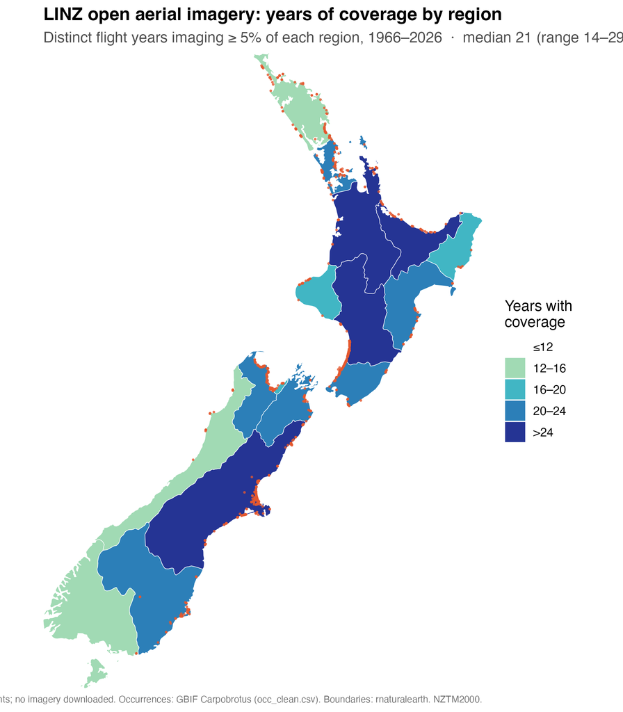

Figure 2: LINZ open aerial **number of years with imagery**, by region — distinct flight years imaging ≥ 5% of the region, 1966–2026 (survey-index footprints, Spain’s method). Median 21 (range 14–29). Orange = GBIF *Carpobrotus* occurrences.

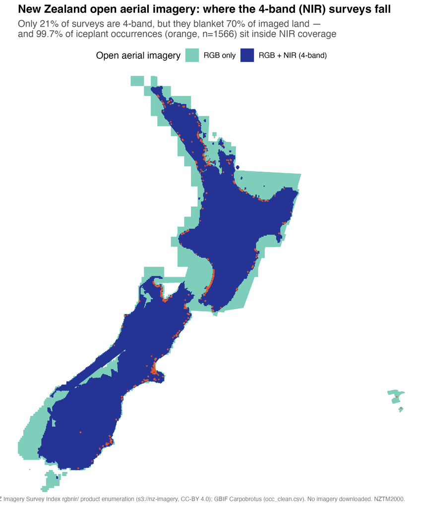

Figure 3: **Where the 4-band (NIR) surveys fall.** Dark blue = imaged land with RGB+NIR, teal = RGB only; orange = GBIF *Carpobrotus* occurrences. Only 21% of surveys are 4-band, but they cover ~70% of imaged land and 99.7% of occurrences — the RGB-only gaps are the alpine interior, not the coast (`avail_nz_nir_audit.R`).

*Full written notes: **Appendix — New Zealand**.*

**France — IGN BD ORTHO**

**Iceplant species (GBIF-seeded):** 5 named (+ *sp.*): *C. acinaciformis, C. chilensis, C. deliciosus, C. edulis, C. glaucescens* (+ *acinaciformis × edulis*).

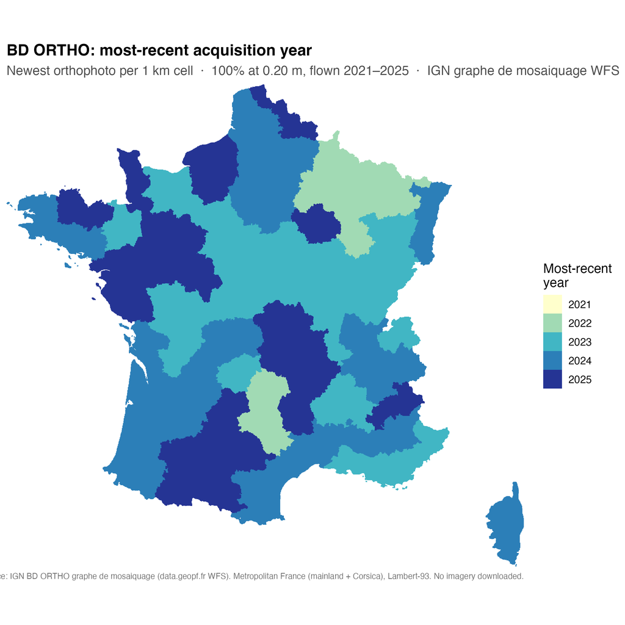

Figure 4: BD ORTHO **most-recent acquisition year** — newest orthophoto per 1 km cell (IGN *graphe de mosaïquage* WFS). 100% of the land at 0.20 m, flown 2021–2025.

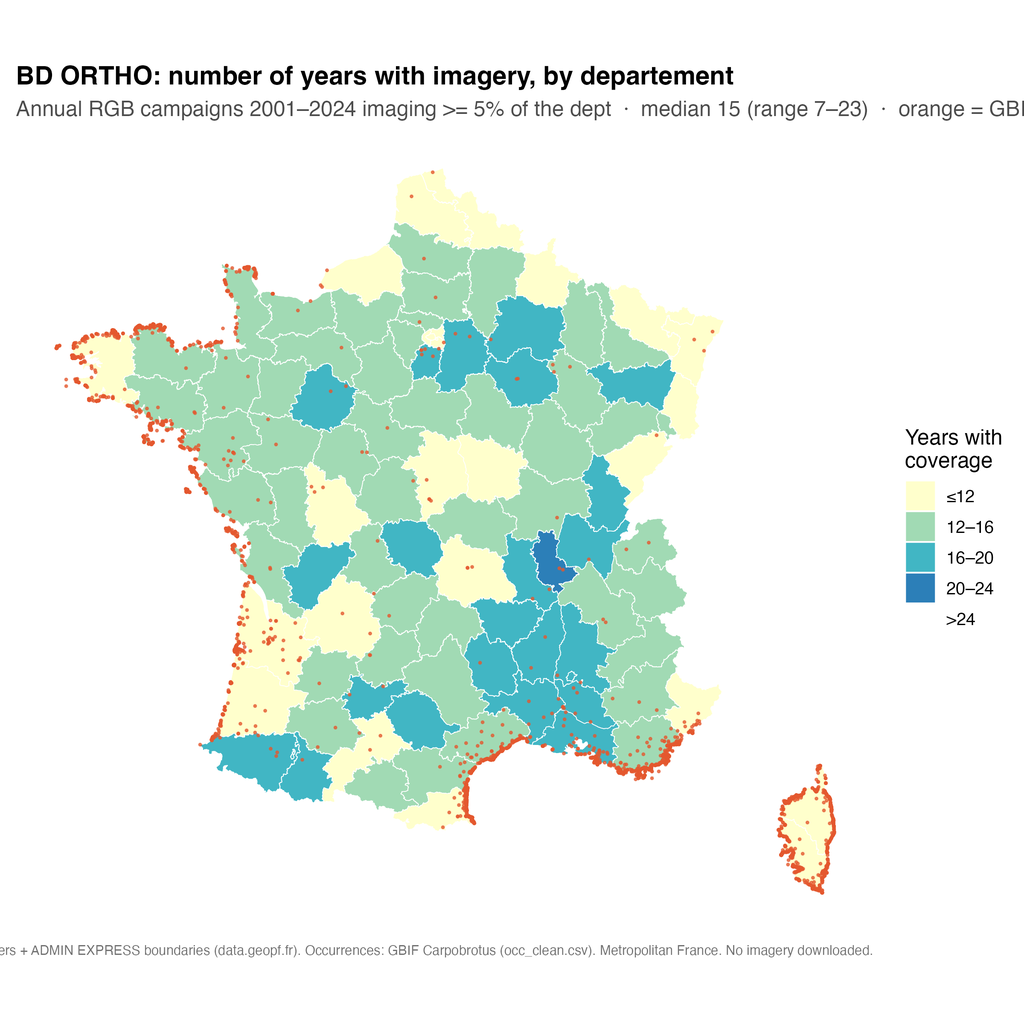

Figure 5: BD ORTHO **number of years with imagery**, by département — annual RGB campaigns 2001–2024 imaging ≥ 5% of the département (per-year WMS masks, Spain’s method). Median 15 (range 7–23). Orange = GBIF *Carpobrotus* occurrences (metropolitan France).

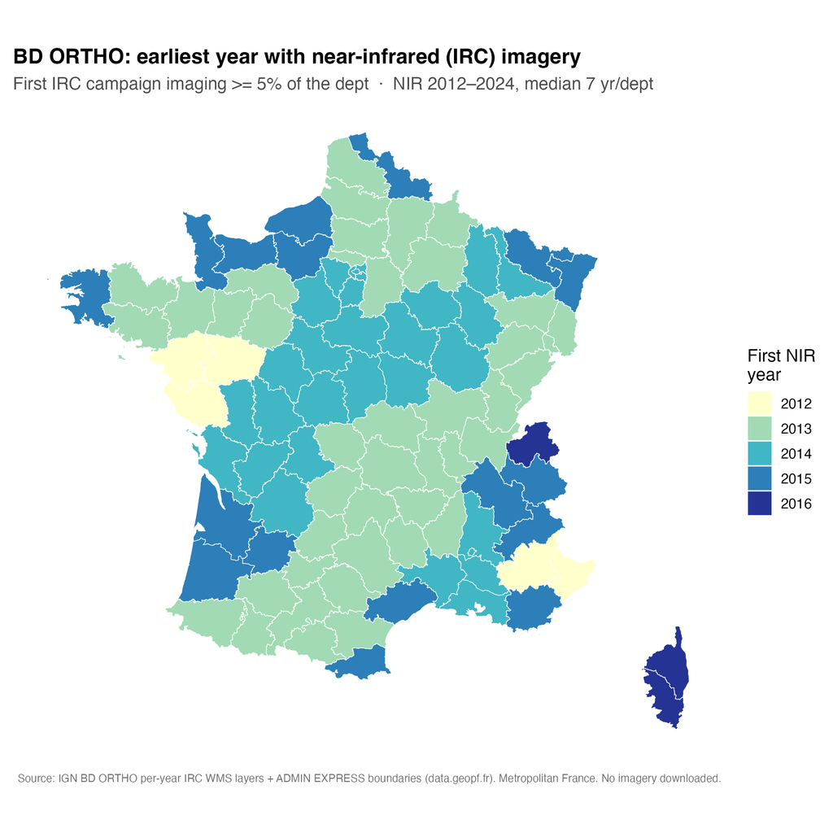

Figure 6: BD ORTHO **earliest year with near-infrared (IRC) imagery**, by département. Per-year IRC layers available 2012–2024; a small 2012 first appearance (5 départements), reaching the Mediterranean coast and most of the country by ~2016.

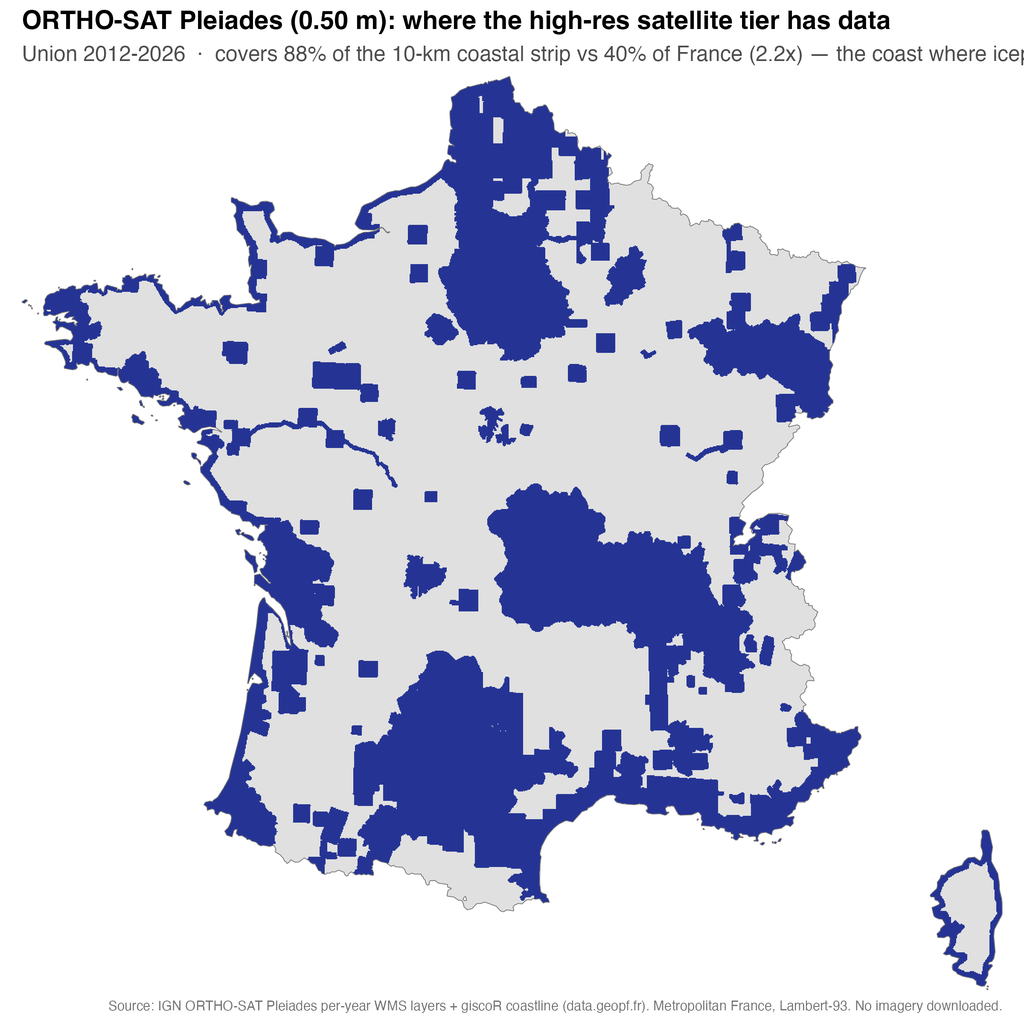

Figure 7: ORTHO-SAT **Pléiades (0.50 m)** footprint (union 2012–2026) over metropolitan France — a near-continuous coastal ribbon (88% of the 10 km coastal strip) plus inland mountains/AOIs. Blue = Pléiades coverage; grey = land.

*Full written notes (incl. the SPOT 6/7 and Pléiades satellite tiers): **Appendix — France**.*

**Portugal — DGT Ortofotos**

**Iceplant species (GBIF-seeded):** 4 named (+ *sp.*): *C. acinaciformis, C. aequilaterus, C. chilensis, C. edulis*.

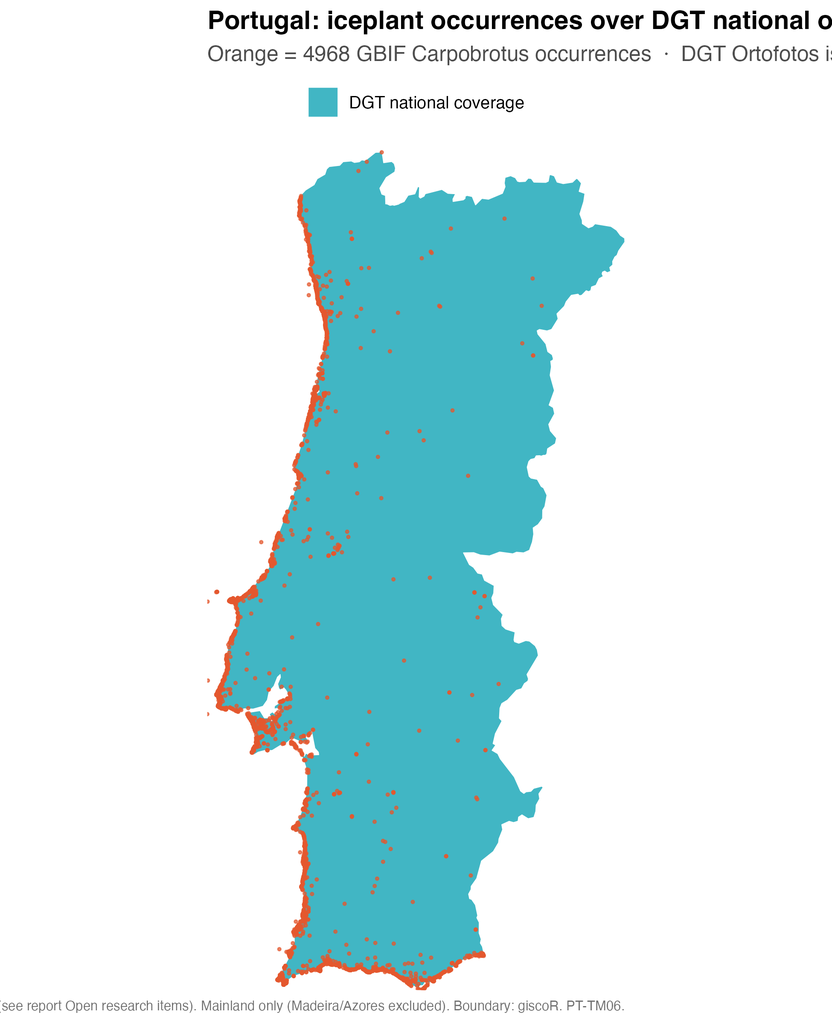

Figure 8: Mainland Portugal — GBIF *Carpobrotus* occurrences (orange) over the DGT national orthophoto programme (uniform national coverage; per-region temporal depth is the open TODO below). Mainland only; Madeira/Azores excluded.

*Full written notes: **Appendix — Portugal**.*

**Spain — IGN PNOA (+ SIGPAC baseline)**

**Iceplant species (GBIF-seeded):** 3 named (+ *sp.*): *C. acinaciformis, C. edulis, C. rossii*.

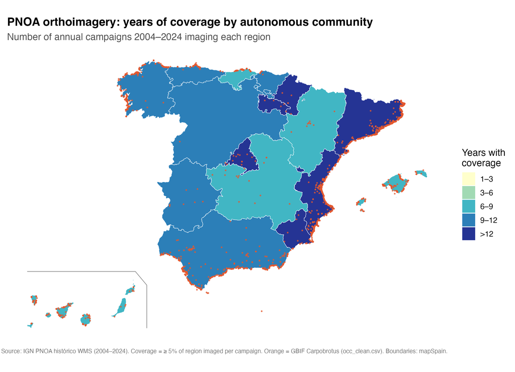

Figure 9: PNOA coverage — number of imaged years per autonomous community, 2004–2024. Orange = GBIF *Carpobrotus* occurrences (Canary Islands relocated with the map), a first look at whether Spanish records sit in coastal vs urban regions.

*Full written notes: **Appendix — Spain**.*

## Climatic similarity

Because the training imagery comes from the **Jack & Laura Dangermond Preserve** in coastal Southern California, a candidate region is only useful if its coast is *climatically* like the preserve. This is assessed with the **Global Environmental Stratification (GEnS v3)** — a 1 km global raster of 125 climate strata grouped into 18 environmental zones — restricted to a **10 km coastal strip** (iceplant is a coastal-dune species). Two similarity tiers are defined relative to the strata covering the preserve: **Tier 1 (closest analog)** = the *same stratum*; **Tier 2 (broad analog)** = the *same 18-class zone*. Total *analog* = Tier 1 + Tier 2.

The preserve is dominantly **strata 71 & 75** (**K. Warm temperate and mesic**), the Tier-1 reference.

**Coastal climate analog to the Dangermond preserve**

10 km coastal strip classified against the preserve's GEnS strata.

|  | **Coastal strip** (km²) | **Tier 1** closest (%) | **Total analog** Tier 1 + 2 (%) | **GBIF occ.** in analog (%) |
| --- | --- | --- | --- | --- |
| Source region (self-check) |  |  |  |  |
| United States of America | 9,490 | 45.8 | 64.3 | 35.1 |
| Target countries |  |  |  |  |
| France | 24,402 | 12.9 | 66.4 | 27.6 |
| New Zealand | 37,663 | 5.7 | 64.3 | 28.9 |
| Portugal | 6,004 | 0.3 | 48.2 | 18.9 |
| Spain | 30,136 | 8.7 | 36.2 | 10.0 |

**Total analog** is the headline figure used in the Summary ranking: **France (66%)** and **New Zealand (64%)** lead, **Portugal (48%)** is middling, **Spain (36%)** trails. *Tier 1* is the strictest match. *GBIF occ. in analog* = share of that country’s *Carpobrotus* records falling inside the analog. **California** is shown only as a self-check (the source region scores high, as expected). Data-derived by `R/climate/analog_gens_dangermond.R`; GEnS v3 (Metzger et al. 2013).

**France**

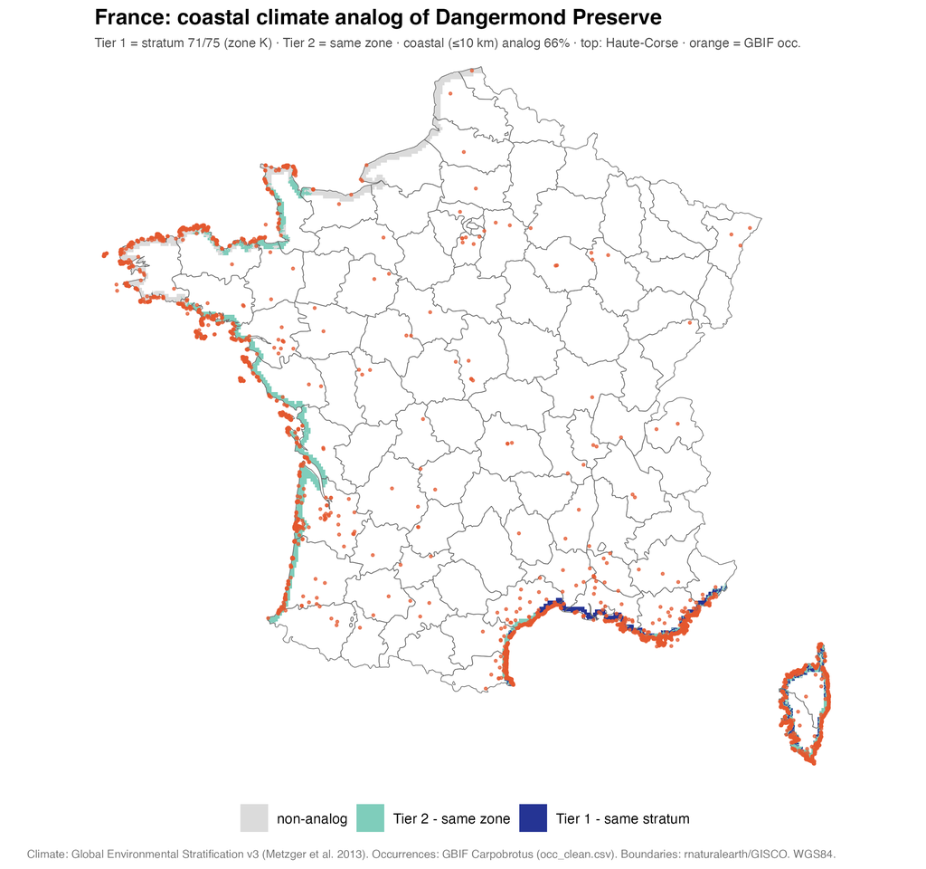

**Spain**

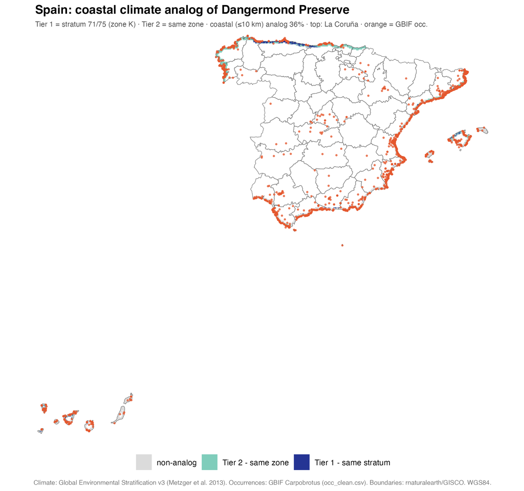

Figure 11: Coastal climate analog — Spain. Best matches on the Atlantic north-west (Galicia, Asturias, Cantabria), not the Mediterranean south-east.

**Portugal**

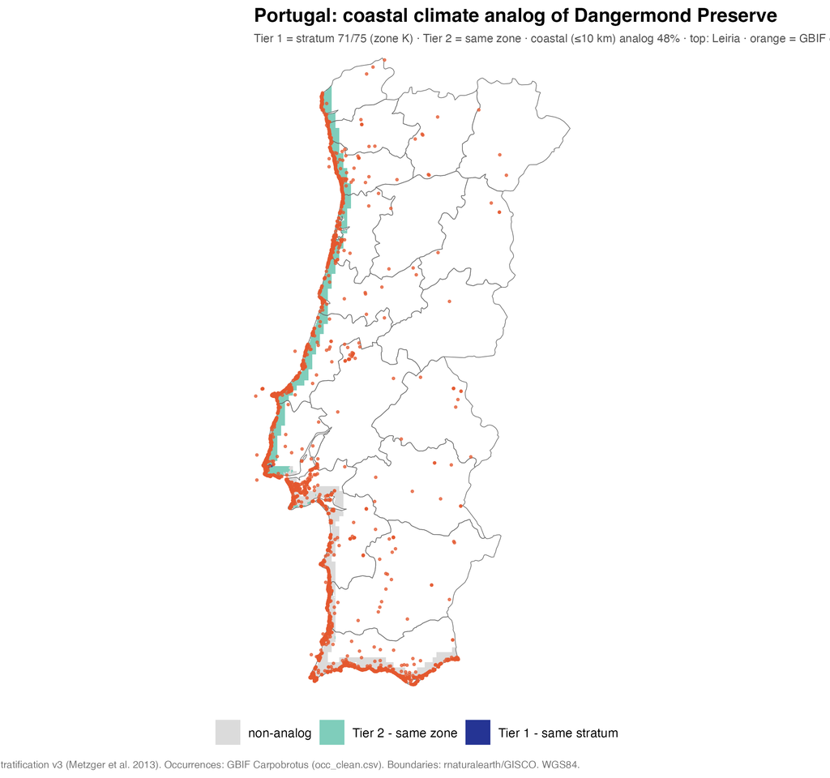

**New Zealand**

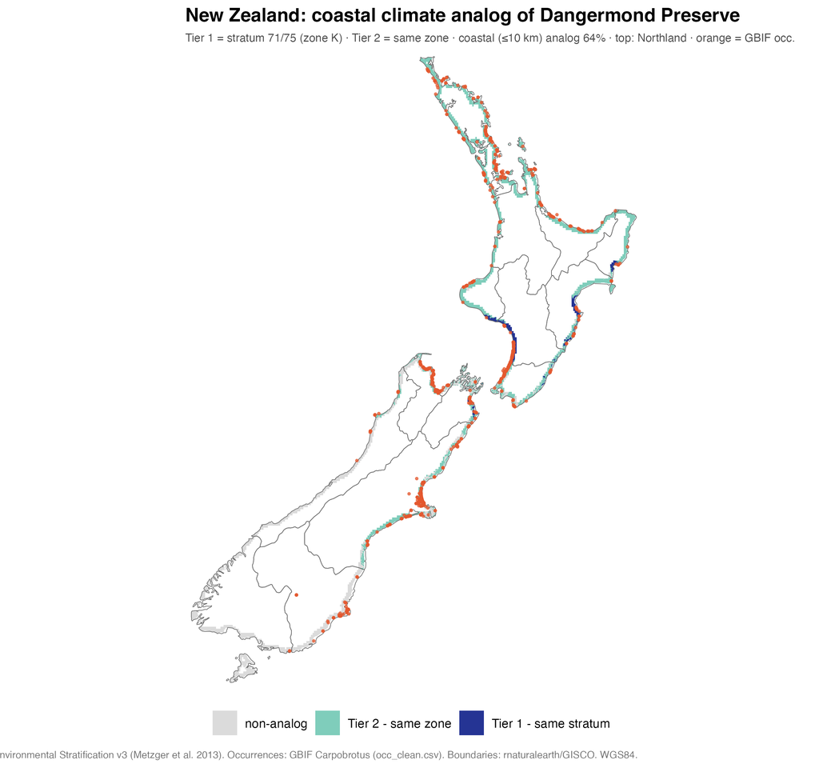

Figure 13: Coastal climate analog — New Zealand. Broad Tier-2 match across the North Island coast (Northland, Waikato) and eastern coasts.

## Conservation overlap

Climatic similarity says *where the coast could support iceplant*; this asks *where the invasion is already on protected land*. Each country’s GBIF *Carpobrotus* records are measured against the **World Database on Protected Areas (WDPA)**, restricted to the same **10 km coastal strip** used above (inland reserves are irrelevant to a coastal-dune species), and scaled to that country’s total occurrences so the ranking is not merely a function of record volume. Proximity is resolved on ~0.46 km H3 hexes, so *inside* means a record’s hex overlaps a protected area.

**France leads:** 83% of its coastal iceplant falls *inside* a protected area (90% within 1 km). The order by share inside a protected area is France 83% > Portugal 76% > Spain 62% > New Zealand 34%.

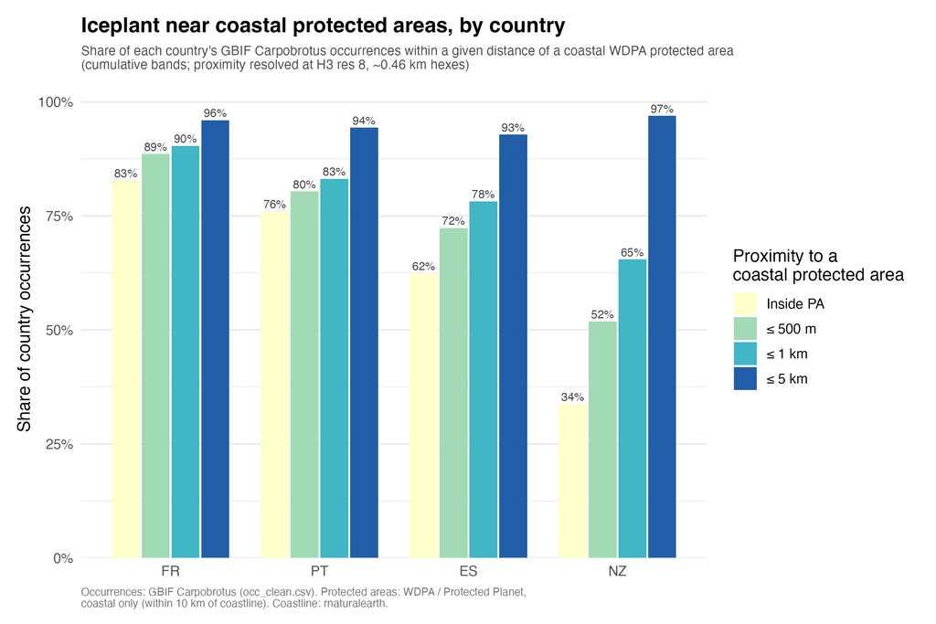

Figure 14: **Iceplant in or near coastal protected areas, by country.** Share of each country’s GBIF *Carpobrotus* occurrences within a given distance of a coastal WDPA protected area (cumulative bands: inside ⊆ ≤500 m ⊆ ≤1 km ⊆ ≤5 km). France highest, New Zealand lowest.

Because iceplant is coastal and these coasts are heavily protected, nearly all records fall within 5 km of a protected area everywhere — so the **inside / ≤1 km** bands carry the signal, not the ≤5 km one. This is a *raw* share, **not** coverage-adjusted: a country with more of its coast protected scores higher by construction, so it answers “where is iceplant most on conservation land”, not “where does iceplant favour protected over unprotected coast”. Data-derived by `R/conservation/prox_wdpa_by_country.R`; protected areas from WDPA / Protected Planet (UNEP-WCMC & IUCN).

## Validation Notes

Examined a few places trying to find potential validation data for each region.

- Google Street View: [example map](https://maps.app.goo.gl/SZGPeNhBakGMjbB87)
- European Vegetation Database
- Literature search for **Carpobrotus** monitoring / mapping / management studies in each country

Results:

- Global Inventory of Vegetation Database (most recent data 2019)
- sPlot vegetation database (most recent plot 2015)
- GBIF sampling events - e.g. surveys that uploaded to GBIF and may have more records; one for Portugal and one for Europe
  - few *Carpobrotus* records in the sampling events
- Google street view: checked GBIF hotspots in each country for streetview
  - Portugal: 8/10 spots found iceplant near GBIF occs
  - France: 5/5
  - Spain: 2/5
  - New Zealand: 3/5
- Portugal has a few prior aerial detection studies with potential for validation
  - [google earth paper](https://zslpublications.onlinelibrary.wiley.com/doi/full/10.1002/rse2.70071)
  - [drone paper](https://doi.org/10.3390/rs15092411)
- Literature:
  - found ~430 papers for carpobrotus
  - 24 related to mapping or extent
  - most from California, Italy, Portgual, Spain - not clear data availability for Med. ones, old

## Open research items

- What is the most interesting comparison to make? e.g., climatic similarity vs. different imagery sources?
- Which site attributes best predict the accuracy of model transfer?
- Do the models perform best in areas most similar to California (factors that tend to influence spectra / RS accuracy, or other site-level factors)?
- Are there findings from the Dangermond work — iceplant density, surrounding landscape, etc. — that should steer location choice?
- How does data get collated for use in the model?
- How will the protocol differ (if at all) for the global extension versus the Dangermond model?
- Do we prefer locations that already have RS identification of iceplant (for comparison), or not?
- Which year(s) are priorities, and how much should that influence site selection?

## Appendix — per-region notes

The detailed written notes for each region, moved out of the Per-region deep-dive so the tabs above stay focused on the maps. Figures are referenced by number and live in that section’s tabs.

### New Zealand — LINZ open aerial

Easiest access of any candidate: anonymous public COGs on `s3://nz-imagery` (`ap-southeast-2`), no account, CC-BY 4.0; native CRS **EPSG:2193** (NZTM2000, metres). 4-band (`rgbnir/`) exists as a sibling prefix beside `rgb/` for ~22% of surveys — the reproducible figure from `R/imagery/avail_nz_nir_audit.R`. Temperate rather than Mediterranean, so a more demanding climatic transfer test than the European sites.

**The NIR band is verified and, crucially, it reaches the sites that matter.** The 22% was re-checked three ways in `avail_nz_nir_audit.R`: (i) *every* product folder in the bucket was enumerated — only `rgb` and `rgbnir` exist, so the count is complete, not an undercount from a missed `rgbi/`-style variant; (ii) the COG headers confirm the band content — an `rgb/` tile carries 4 bands (R, G, B, alpha) and its `rgbnir/` sibling 5 (R, G, B, **NIR**, alpha); (iii) the 4-band footprints were overlaid on the cleaned GBIF occurrences. The headline “22% of surveys” badly understates NIR’s usefulness here: the 4-band surveys are the large modern regional programmes, so they **blanket ~70% of all imaged NZ land and contain 99.7% of the iceplant occurrences (1,561 of 1,566)** — the RGB-only gaps are the alpine interior, not the coast (see Figure 3).

**Open questions:** which validation data beyond GBIF (dune/vegetation monitoring, prior RS detections). *Resolved this pass:* NIR **is** verified 4-band and aligns with the occurrence areas (99.7% of records sit inside a 4-band footprint — see Figure 3).

### France — IGN BD ORTHO

Second **data-derived** coverage product (after Spain), from two IGN web services on `data.geopf.fr` (no imagery downloaded), built by `R/imagery/avail_fr_bdortho_coverage.R`. The BD ORTHO *graphe de mosaïquage* WFS gives, per acquisition block, the capture year, resolution and exact flight date (→ current-mosaic recency, resolution, seasonality); the per-year `ORTHOPHOTOS<year>` WMS layers each render only the ground flown that year — the same per-campaign-mask idea as Spain’s PNOA, so France’s coverage metrics are computed **identically to Spain and are directly comparable**.

BD ORTHO is **complete, wall-to-wall national coverage** — every département, rural and urban alike — imaging both metropolitan France and the overseas territories (DROM); the figures in the tab are scoped to **metropolitan France (mainland + Corsica)**, since the overseas territories can’t share one metric projection. Findings:

- **Resolution / recency.** The current best-available mosaic is **100% of the land at 0.20 m, all flown 2021–2025** (older editions ran to 0.50 m, so the record spans 0.20–0.50 m; Figure 4).
- **Cadence.** Each annual campaign images **≈ 32% of the country** (range 20–44%, 2001–2024) → a **~3-year full refresh** (cf. Spain ≈ 36%).
- **Temporal depth.** A typical département has new imagery in **15 of the 24 years** 2001–2024 (range 7–23; years imaging ≥ 5% of the département), comparable to Spain’s 12 — so most sites carry a deep multi-date stack for change detection (Figure 5).
- **Seasonality.** Flights are strongly spring–summer — **70% of the area Apr–Jul, 100% Mar–Oct** — leaf-on and overlapping iceplant flowering.
- **NIR/IRC (the iceplant-relevant band).** BD ORTHO is *acquired* 4-channel (R/G/B/NIR) but *delivered* as two separate 3-band products — RGB and IRC (near-infrared false-colour, NIR/R/G); there is **no single 4-band file**, so the NIR comes via the IRC product (IGN *Descriptif de contenu BD ORTHO 2.0*). Per-year IRC layers exist **2012–2024** (probed from the WMS `GetCapabilities`, not assumed): a small first appearance in **2012** (5 départements, ~2% of France), ~25% by 2013, reaching essentially the whole country — Mediterranean coast included — by **~2016** (younger than RGB, but now nationwide; Figure 6).

Licence Ouverte (Etalab); `data.geopf.fr` also feeds the zoom-in chips in `R/imagery/fig_hires_zoomins.R`/`fig_tight_grid.R`. Mediterranean south coast is climatically close to Southern California.

**Satellite complement — ORTHO-SAT (SPOT 6/7).** Alongside the triennial 0.20 m aerial, IGN publishes an **annual national satellite mosaic**: SPOT 6/7 at **1.5 m, every year since 2014** (metropolitan; overseas since 2015) — verified here as ~100% land coverage in each per-year WMS layer (`ORTHOIMAGERY.ORTHO-SAT.SPOT.<year>` on `data.geopf.fr`). It trades resolution for cadence: coarser than the aerial, but a same-year wall-to-wall snapshot, ideal for **annual change detection** to bracket when an infestation appeared between the 3-yearly high-res passes. Per IGN’s ISO 19115 metadata the product is **4-band — R, V, B and PIR (near-infrared)**, pan-sharpened and distributed as GeoTIFF, so the **NIR band is available** with the data product (the open geopf WMS just renders natural-colour RGB by default; there is no separate IRC render layer as there is for BD ORTHO). Licence Ouverte (IGN frames the SPOT millésimes as for institutional actors, but the formal metadata licence is open).

**Higher-resolution tier — ORTHO-SAT Pléiades (0.50 m), and it’s coastal.** Pléiades (0.50 m, 2012→) is *not* wall-to-wall — acquisitions are opportunistic — so its cumulative ~40% of France looks weaker than the aerial or SPOT at first glance. But the footprint is **strongly biased to the coast**: pooling all years, Pléiades covers **88% of the 10 km coastal strip vs 40% of France overall (2.2× the national rate)** — it blankets almost the entire coastline at 0.50 m (`R/imagery/avail_fr_orthosat_coverage.R`). For a coastal-dune species that is exactly the right partial coverage: a near-complete 0.50 m, 4-band (incl. NIR) coastal layer, finer than SPOT and denser in time than the 3-yearly aerial. The inland Pléiades blobs are mountains, cities and one-off AOIs (Figure 7).

**Open questions:** French national validation data (e.g. conservatoires botaniques / dune monitoring); and, for the specific dune occurrence polygons, the exact flight *year* + month of the newest NIR frame (derivable per-AOI from the same graphe/per-year layers).

### Portugal — DGT Ortofotos

Native RGB+NIR 4-band, ~0.25 m from 2018 (0.50 m earlier), ~3-yr cadence; open via dados.gov.pt and the DGT WMS/WMTS. Atlantic–Mediterranean climate close to SoCal, and the region with prior remote-sensing detection work on iceplant to compare against.

Portugal is the one region without a data-derived per-region coverage product yet, so the map in the tab shows only the **GBIF occurrences over the DGT national programme** (coverage is national, hence effectively uniform — no per-region year counts are implied). The occurrences concentrate on the southern and western coast, exactly where the deep-dive would train (Figure 8).

**Open questions:** confirm the newest 25 cm footprint over the southern (Algarve) dune sites; API/portal coverage end-year; seasonality; and the data-derived per-region coverage / temporal-depth analysis still owed here — the counterpart to the NZ/France/Spain maps (see Figure 8 for the occurrence context).

### Spain — IGN PNOA (+ SIGPAC baseline)

**Open questions (from project notes):** is Spanish iceplant mostly **urban** rather than coastal-dune? That would change both the training imagery and the transfer framing — worth checking the occurrence distribution before choosing Spain (the occurrences are overlaid on Figure 9 for a first look). Also: NIR (false-colour IR) availability per region and per year; seasonality.

*Generated 2026-09-09 from the iceplant-extension project — scaffold pass, unresearched cells marked `TODO`.*